# Project 2 Interrogation

Jelly Dongyi Guo - 470033070

University of Sydney | MATH1115 | November 2021

# 1 Interrogation: Chi-square Test (Goodness of Fit)

> **Research Question:** Which city would be the best choice to fly in for Mr. Pargon’s travel around Australia from United States? Which month would be when the airports are the least crowded? Is this “least crowdedness” having a disparity in the proportion between different destination cities?
- This question is originally from peer Rohan Dixit (SID: 500457896): “When should Mr. Pargon Travel?”

## 1.1 Clean the data

Firstly,the data set will be cleaned to opt out any irrelevant variables, and for our investigation, entries from 2003 and 2021 are also removed since we don’t have a whole-year record on them:

```r
# Prepare Data
read_csv("data/data.csv", name_repair = janitor::make_clean_names) %>%
  filter(in_out == "I") %>%
  filter(port_country == "USA") %>%
  filter(year != 2021) %>%
  filter(year != 2003) %>%
  mutate(month_num = factor(month_num)) %>%
  select(-month, -in_out, -international_city, -port_country, -service_country, -service_region, -airline, -route, -stops, -year, -port_region) -> data
```

## 1.2 Find the least crowded month

Then our goal is to figure out the least crowded city and month based on past observations of number of flights and seats provided, for the month:

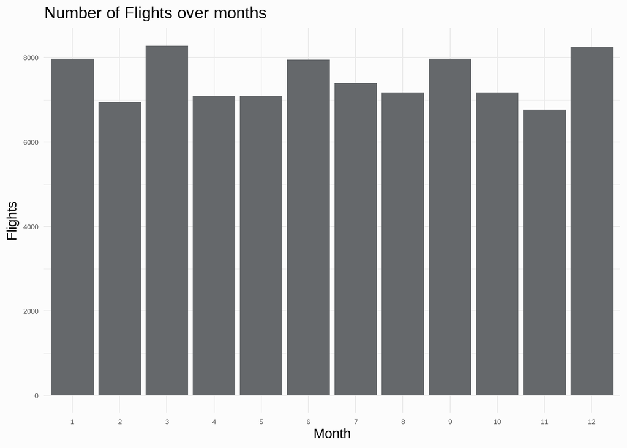

```r
data %>%
  select(month_num, all_flights,max_seats) %>%
  plyr::ddply("month_num", plyr::numcolwise(sum)) -> table_of_months

table_of_months %>%
  ggplot(aes(x = month_num, y = all_flights)) +
  geom_bar(stat = "identity") +
  ggtitle("Number of Flights over months") +
  xlab("Month") +
  ylab("Flights") +
  theme_minimal() +
  geom_blank()
```

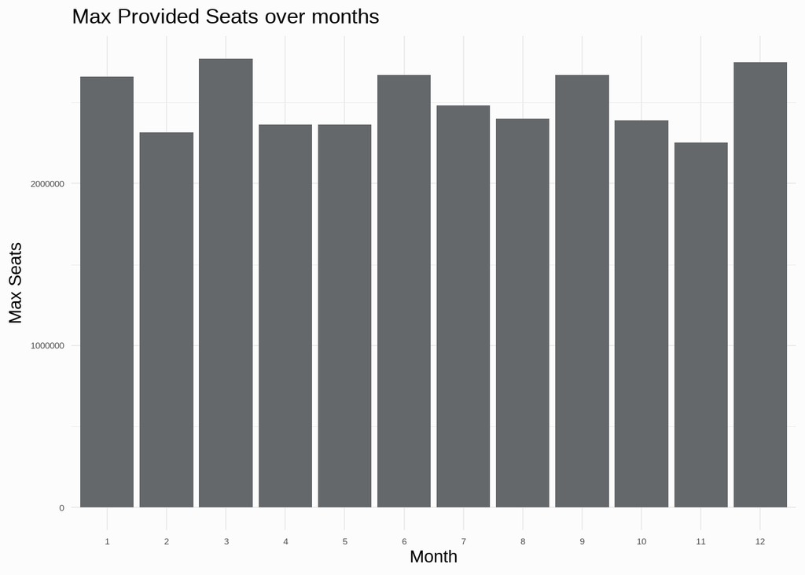

```r
table_of_months %>%
  ggplot(aes(x = month_num, y = max_seats)) +
  geom_bar(stat = "identity") +
  ggtitle("Max Provided Seats over months") +
  xlab("Month") +
  ylab("Max Seats") +
  theme_minimal() +
  geom_blank()
```

For the month it is quite obvious that November is having the least number of flights or seats capacities, with only 6767 running flights and 2250901 provided seats.

## 1.3 Find the least crowded city

Now we will be looking into the least crowded city that taking flights from Unite States:

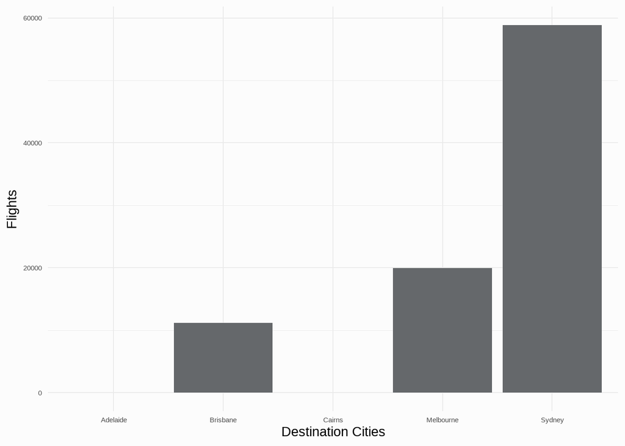

```r
data %>%
  select(australian_city, all_flights,max_seats) %>%
  plyr::ddply("australian_city", plyr::numcolwise(sum)) -> table_of_city

table_of_city %>%
  ggplot(aes(x = australian_city, y = all_flights)) +
  geom_bar(stat = "identity") +
  xlab("Destination Cities") +
  ylab("Flights") +
  theme_minimal() +
  geom_blank()
```

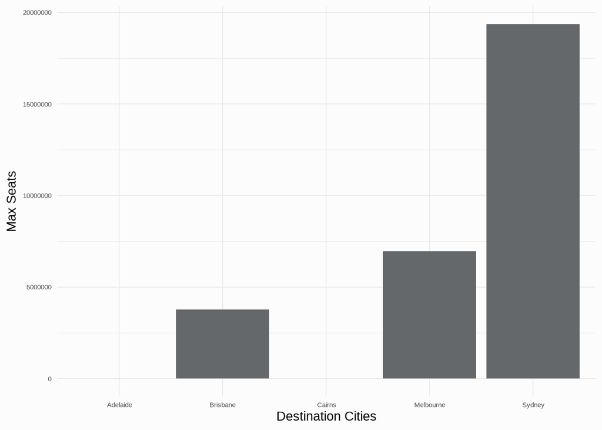

```r
table_of_city %>%
  ggplot(aes(x = australian_city, y = max_seats)) +
  geom_bar(stat = "identity") +
  xlab("Destination Cities") +
  ylab("Max Seats") +
  theme_minimal() +
  geom_blank()
```

It turns out there are only 5 cities in Australia having flights communicating with the United States, while Adelaide and Cairns are having only 2 flights arrived in Australia from 2004 to 2020 on record. Sydney has over double of both the number of flights and seat capacities of Melbourne, where Brisbane has only half of both properties of Melbourne.

The issue is: although Adelaide and Cairns have the least crowdedness on record, they only had the 2 flights run on early of the June between 2006 and 2008, and they are never appeared after. This promises nothing for Mr. Pargon to be able to travel with this flights in future and may indicate these flights were not regulated operation for delivering normal passengers. Thus, Brisbane stands out for being the least crowded destination city in Australia for Mr. Pargon to travel in from United States.

Now the question becomes:

> **Is there a city disparity in the proportion of least frequently traveled months between Sydney and others?**

## 1.4 Goodness of Fit

This is the time when a chi-square test kicks in to help with a standard HATPC procedure. However, as mentioned before, since Adelaide and Cairns are special cases, they will be removed from this analysis.

```r
data %>% filter(australian_city != "Adelaide") %>% filter(australian_city != "Cairns") -> data
```

Firstly, hypothesizes are pulled up:

- $H_0$ (Null Hypothesis): The crowded distribution in month of Sydney is same as other cities.
- $H_1$ (Alternative Hypothesis):The crowded distribution in month of Sydney is **NOT** same as other cities.

```r
# Total flights
flight_sum <- sum(table_of_months$all_flights)

# Get EV
table_of_months %>%
  select(all_flights) %>%
  mutate(all_flights = all_flights / flight_sum) %>%
  pull(all_flights) -> expected

# Get Sydney's number of flights distribution by months
data %>%
  filter(australian_city == "Sydney") %>%
  select(month_num, all_flights) %>%
  plyr::ddply("month_num", plyr::numcolwise(sum)) %>%
  as_tibble() -> flights_by_months_SYD

observed <- flights_by_months_SYD$all_flights
```

Assumptions are checked below based on the observed and expected possibility calculated above since the data are quite independently collected (third-parties):

```r
sum(observed) * expected
```

```
##  [1] 5209.821 4541.912 5416.539 4634.804 4634.804 5194.120 4833.018 4688.446
##  [9] 5212.437 4691.063 4426.777 5396.259
```

```r
chisq_test <- chisq.test(observed, p = expected)
chisq_test
```

```
##
##  Chi-squared test for given probabilities
##
## data:  observed
## X-squared = 5.266, df = 11, p-value = 0.9176
```

Here the test statistics are revealed here as 5.2660097 and the P-value 0.9176024 is almost 1 at a 5% level of confidence. Thus, the null hypothesis is retained and the alternative hypothesis is rejected.

## 1.5 Conclusion

This made us come to our conclusion: It seems like no matter which city Mr. Pargon decides to land to start the journey, November is always a great choice to avoid being flooded by other travelers and having a peaceful, great and enjoyable time in Australia. If Mr. Pargon is hesitating on where to land first with least crowdedness, Brisbane will be the best place to say goodbye to the winter of northern hemisphere and welcome Mr. Pargon with an Australian summer.